# What factors are significant for predicting whether credit card payments will default?

Zhuo Feng Lei (zlei5)

2/10/2020

# Abstract

In order to avoid significant financial losses, banks must be able to recognize whether consumers will default on their credit card payments. Statistical machine learning methods and techniques are utilized to find an accurate model that best classify default payments.

# Introduction

Credit cards are flexible tools issued by banks to consumers. It enables the cardholder to pay a merchant for goods and services based on the cardholder’s promise to the card issuer to pay them for the amounts plus other agreed charges by the due date listed on the credit card statement. When a customer fails to pay back the loan by the due date, the credit card will be defaulted. If the bank is certain that they will not get their money back, the bank will try to sell the loan. If the bank are unable to sell off the loan to debt collectors, the bank will write off the loan (charge-off). As a result, the customer’s credit ratings tanks while the bank suffers significant financial losses.

Risk prediction is a powerful tool that can be utilized by banks and other financial service providers. Risk predictions is essential for predicting customer’s credit risks or business performances. The ability to predict which customers are most probable to default on payments will allow banks to reduce damages and uncertainty when issueing credit cards to customers. Analyzing millions of transactions and client information to make a prediction is both resource and time consuming and prone to errors. Therefore, it is more efficient to use machines to compute and analyze the data. Currently, a variety of machine learning approaches are used to predict default payments. [^1] Through machine learning, the goal of this project is to implement a model that can accurately classify whether loans will default or not based on certain features.

# Data

The data was accessed via Kaggle. [^2] The dataset contains information on default payments, demographic factors, credit data, history of payment, and bill statements of credit card clients in Taiwan from April 2005 to September 2005. The dataset have 30,000 observations and 25 variables. The response variable is *default.payment.next.month*, whether the payment will default next month.

The input variables are:

- LIMIT_BAL: Amount of given credit in NT dollars (includes individual and family/supplementary credit

Higher limit balance indicates a higher credit score. Clients with higher credit scores are deemed more reliable and trustworthy

- SEX: Gender (1=male, 2=female)

Gender wage gaps. Men may earn more money than women in some workplaces. Having high wages usually indicates that clients are able to pay back the business

- EDUCATION: (1=graduate school, 2=university, 3=high school, 4=others, 5=unknown, 6=unknown)

Higher education means higher income.

- MARRIAGE: Marital status (1=married, 2=single, 3=others)

Having kids cost money. Being married and having kids may affect defaulting. On the other hand, married couples may have dual income which may help pay credit card payments

- AGE: Age in years

Younger adults may still be in school or have entry level jobs that doesn’t pay as much as senior positions. This may have an effect on whether payments will default or not

- PAY_0: Repayment status in September, 2005 (-1=pay duly, 1=payment delay for one month, 2=payment delay for two months, … 8=payment delay for eight months, 9=payment delay for nine months and above)
- PAY_2: Repayment status in August, 2005 (scale same as above)
- PAY_3: Repayment status in July, 2005 (scale same as above)
- PAY_4: Repayment status in June, 2005 (scale same as above)
- PAY_5: Repayment status in May, 2005 (scale same as above)
- PAY_6: Repayment status in April, 2005 (scale same as above)

Repayment status helps determine how clients are doing financially. Delayed payments indicate that clients are having difficulties paying back the money they owe

- BILL_AMT1: Amount of bill statement in September, 2005 (NT dollar)
- BILL_AMT2: Amount of bill statement in August, 2005 (NT dollar)
- BILL_AMT3: Amount of bill statement in July, 2005 (NT dollar)
- BILL_AMT4: Amount of bill statement in June, 2005 (NT dollar)
- BILL_AMT5: Amount of bill statement in May, 2005 (NT dollar)
- BILL_AMT6: Amount of bill statement in April, 2005 (NT dollar)

A high bill amount may indicate bad spending habits which may have an effect on defaulting payments

- PAY_AMT1: Amount of previous payment in September, 2005 (NT dollar)
- PAY_AMT2: Amount of previous payment in August, 2005 (NT dollar)
- PAY_AMT3: Amount of previous payment in July, 2005 (NT dollar)
- PAY_AMT4: Amount of previous payment in June, 2005 (NT dollar)
- PAY_AMT5: Amount of previous payment in May, 2005 (NT dollar)
- PAY_AMT6: Amount of previous payment in April, 2005 (NT dollar)

# Summary Statistics

### Univariate Analysis

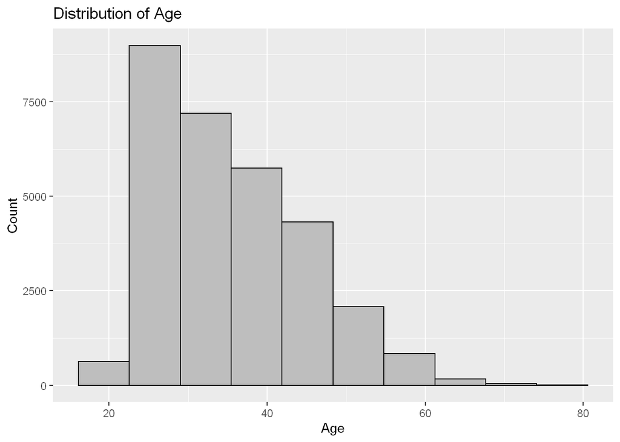

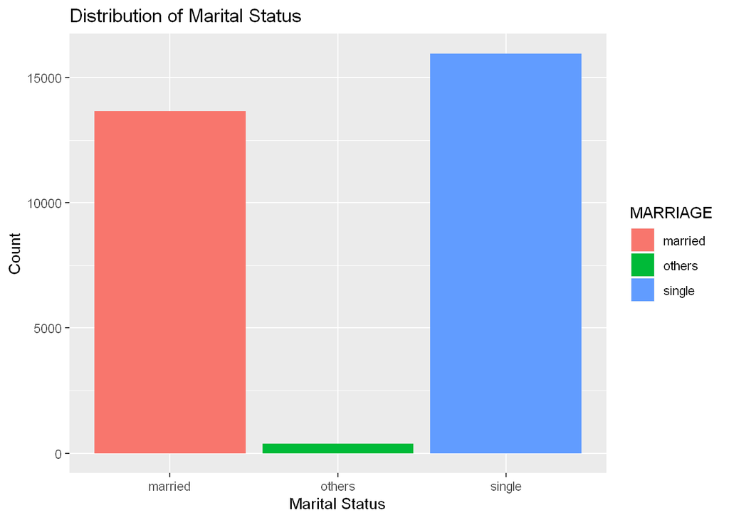

The sample distribution of marital status are roughly even.

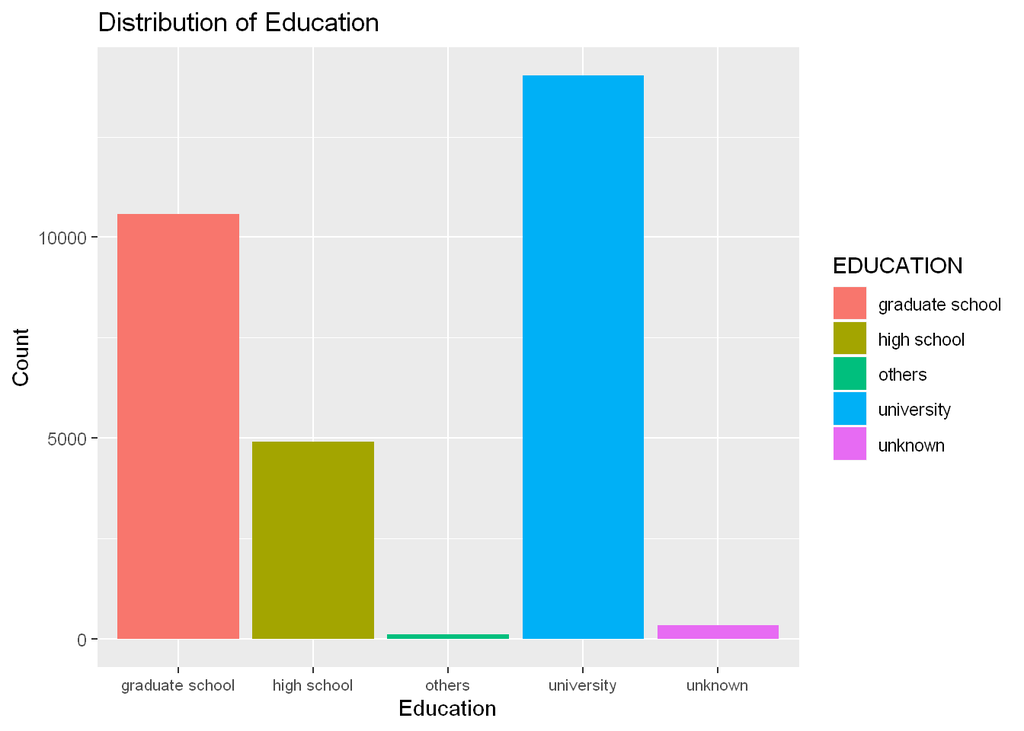

Most of the client’s either have graduate school or university as their highest form of education. The third most group is high school.

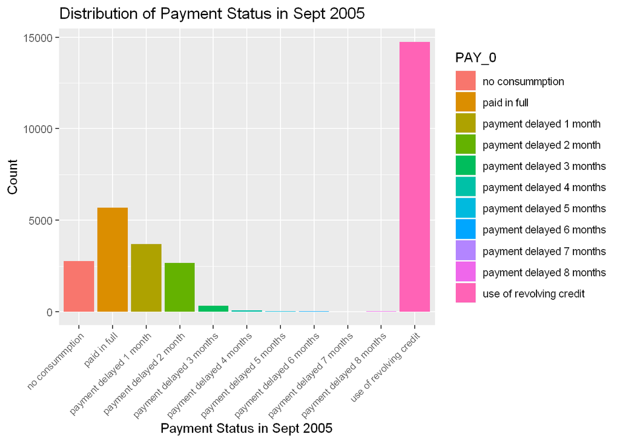

It appears that clients mostly use revolving credit for their payments in Sept 2005. Stagnant wages coupled with the rising cost of living may cause people to live paycheck to paycheck. As a result, many people may not be able to pay off all their credit card bill and use revolving credit. The second most frequent status is clients paying off all their balance.

### Bi-variate Analysis

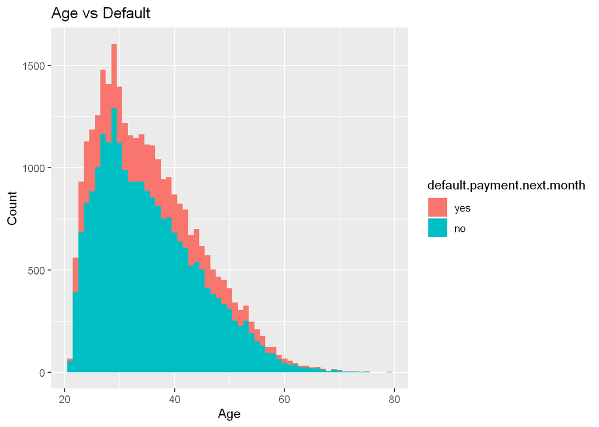

The age distribution for default payments are more skewed than the age for non-default payments. Many people that default in their next month payments are in their 20s to 40s. As age increases, the number of default payments seem to decrease. It appears that age hae a significant effect on whether payments will default, but additional analysis is needed to determine if this is truly the case.

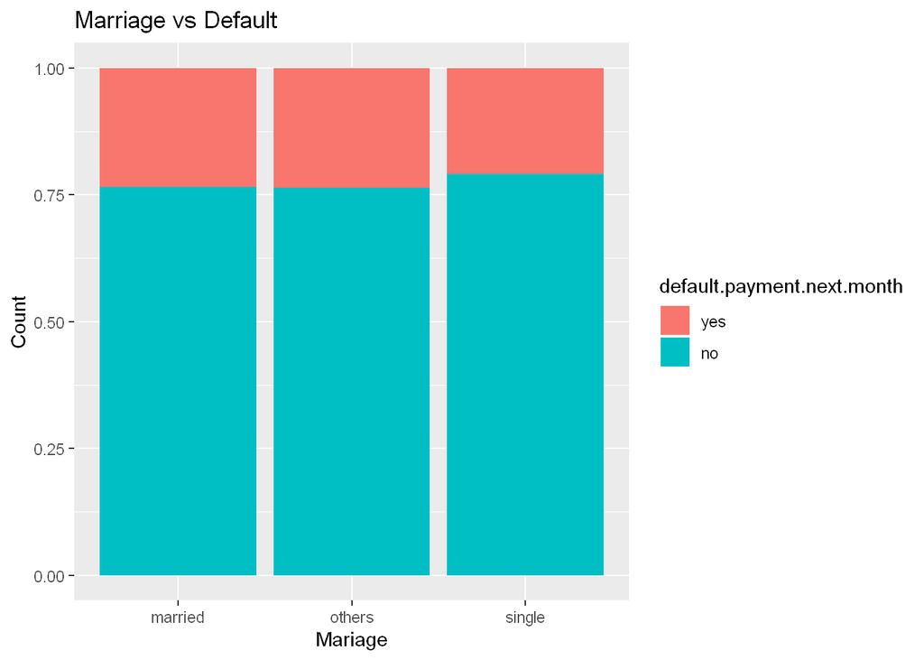

It appears that marital status does not have significantly affect whether payments will default since all three groups have roughly the same ratio of default payments in their respective groups. Additional analysis is needed to to determine whether marital status have any significant effects on default payments.

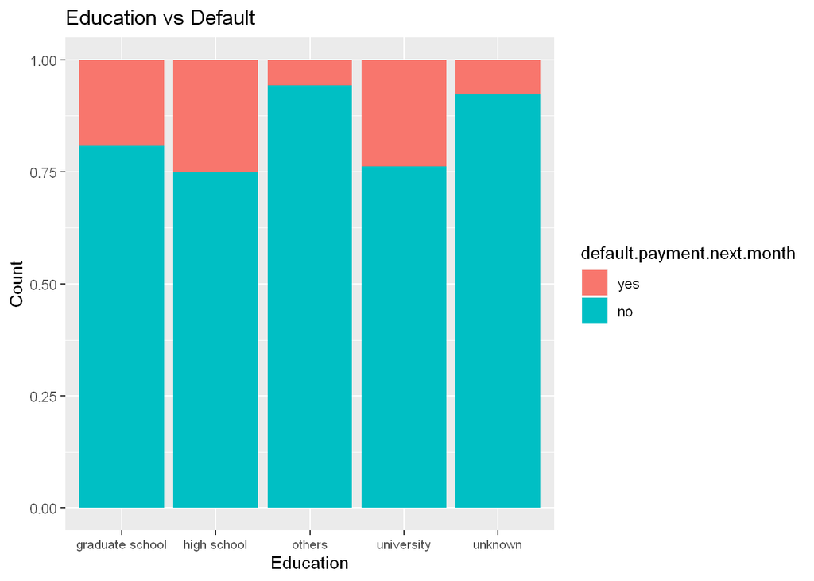

Clients whose highest education was university or highschool have the largest ratio of default payments. In the case of university, this may be due to student loans or field of studies. In the case of highschool, clients may not have high income due to the lack of higher education. Additional analysis is needed to determine if education have any significant effect on whether payments will default.

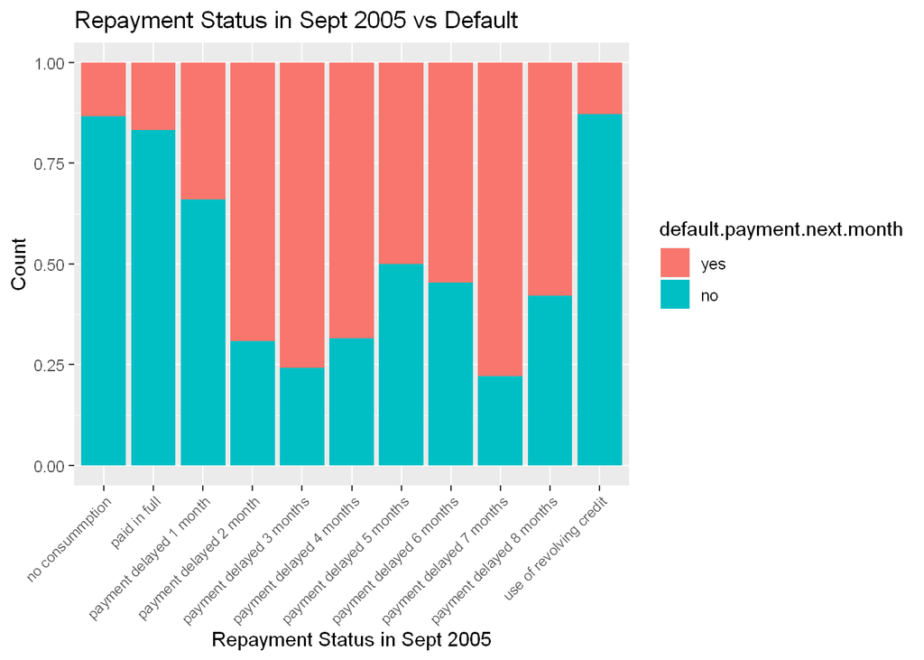

It appears that the payments that are delayed for 2,3,4 or 7 months have the highest ratio of default payments in their respective populations. Additional analysis is needed to determine if repayment status have any significant effects on the outcome.

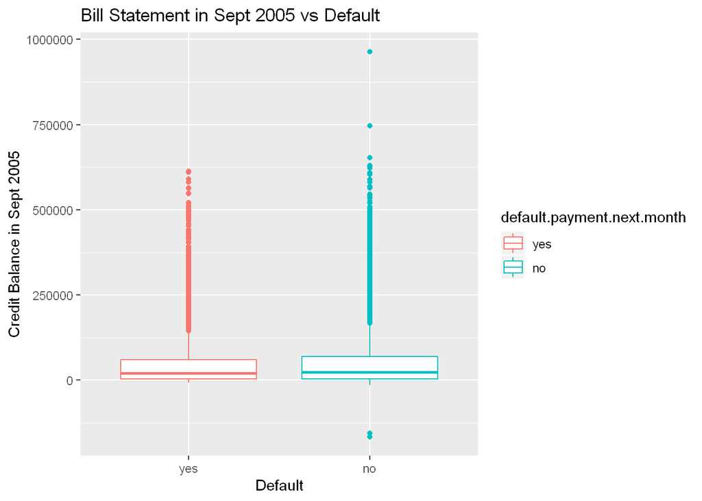

Since the confidence intervals for both boxplot overlap, the difference between the two groups seems insignificant. It does not seem that credit balance in Sept 2005 have a significant effect on whether the payment next month will default or not. Additional analysis is required.

# Modeling

In order to build a classifier to predict whether payments will default, different modeling techniques were considered: K’s Nearest Neighbor, Logistic Regression, and Probit Regression.

### Logistic Regression

| Model | Accuracy |
| --- | --- |
| Logistic Regression Model 1 | 0.8214776 |
| Logistic Regression Model 2 | 0.7971429 |
| Logistic Regression Model 3 | 0.8200486 |
| Logistic Regression Model 4 | 0.8210481 |
| Logistic Regression Model 5 | 0.8210489 |

The best logistic model is the one with all the predictors except ID. Independent features with p-value less than .05 have a significant effect on the dependent feature (whether payments will default or not in the next month) and their coefficients are significantly different from zero. Features with lower p-values have a larger effect on the outcome. According to the summary of the logistic regression mod with all the features, some of the significant features are the balance limit on the account, the male gender, unknown education status, how much the client paid in the first and second month, and repayment status in the first month.

```
##                       LIMIT_BAL                         SEXmale
##                    1.852798e-06                   -1.883685e-01
##          `EDUCATIONhigh school`             EDUCATIONuniversity
##                    6.561628e-02                   -1.418319e-02
##                  MARRIAGEothers                             AGE
##                    8.667289e-02                   -3.416999e-03
##  `PAY_0payment delayed 1 month`  `PAY_0payment delayed 2 month`
##                   -8.810109e-01                   -2.123550e+00
## `PAY_0payment delayed 3 months` `PAY_0payment delayed 4 months`
##                   -2.143407e+00                   -1.726956e+00
## `PAY_0payment delayed 5 months`  `PAY_2payment delayed 1 month`
##                   -6.706212e-01                    3.719730e-01
## `PAY_3payment delayed 3 months` `PAY_3payment delayed 4 months`
##                   -5.319631e-01                    8.325471e-02
## `PAY_4payment delayed 5 months` `PAY_6payment delayed 4 months`
##                    4.563092e-01                    3.679199e-02
##                       BILL_AMT1                        PAY_AMT2
##                    1.258920e-06                    9.862795e-06
##                        PAY_AMT3
##                    4.270652e-07
```

The table above displays a list of all significant variables and their respective coefficients.

- For every unit increase in LIMIT_BAL (balance limit on the account), the log odds of defaulting increases by 1.852798e-06.
- If the client is male, the log odds of defaulting decreases by 1.883685e-01.
- If education is in the others category, then the log odds of defaulting increases by 1.070740e+00.
- If education is unknown, the log odds of defaulting increases by 1.091142e+00.
- If the client is single, the log odds of defaulting increase by 1.093061e-01.
- If client paid in full during their first month, the log odds of defaulting decreases by 6.517546e-01.
- If the payment is delayed for 1 month during the first payment, then the log odds of defaulting decreases by 8.810109e-01.
- If first payment is delayed for 2 months, the log odds of defaulting decreases by 2.123550e+00.
- If first payment is delayed for 3 months, then the log odds of defaulting decreases by 2.143407e+00.
- If first payment is delayed for 4 months, then the log odds of defaulting decreases by 1.726956e+00.
- If second payment is paid in full, the log odds of defaulting increases by 2.882975e-01.
- If third payment is delayed for 2 months, then the log odds of defaulting decreases by 4.027158e-01.
- If fourth payment is delayed for 4 months, then log odds of defaulting decreases by 1.112698e+00.
- If sixth payment is delayed for 3 months, then the log odds of defaulting decreases by 9.270053e-01.
- If sixth payment is paid using revolving credit, then the log odds of defaulting increases by 2.789789e-01.
- For every unit increase in the first payment amount, the log odds of defaulting increases by 1.260881e-05.
- For every unit increase in the second payment amount, the log odds of defaulting increases by 9.862795e-06.
- For every unit increase in the sixth payment amount, the log odds of defaulting increases by 5.201935e-06.

Some of the coefficients from the logistic regression model seems illogical in a real life scenario. I agree that if client’s owe more to the card companies, the odds of defaulting increases. People with high payment amounts are usually bad with money management and live a lifestyle they cannot sustain. However, the model also says that delayed payments reduce the chance of defaulting. It would make more sense if delayed payments increase the chance of defaulting since it indicates that the client cannot financiially pay back the amount owed. It is also interesting to note that being single increases the chances of defaulting. This may be due to the fact that people usually wait until they are financially stable before starting a family (raising kids cost a lot). Being male also lowers the chances of defaulting. This may be caused by the gender wage gaps. Additional modeling and research is needed to verify whether these relationships are true or not.

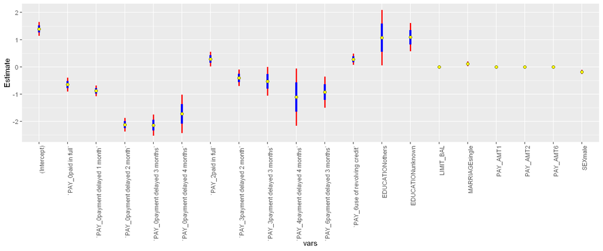

If range of the standard error includes 0, then the independent variable may not be reliable in predicting whether credit card payments will default or not. The range of the standard errors significant variables list previously do not include zeros which means the variables have a significant effect on the dependent variable.

```
## Cross-Validated (10 fold) Confusion Matrix
##
## (entries are percentual average cell counts across resamples)
##
##           Reference
## Prediction  yes   no
##        yes  8.0  3.7
##        no  14.2 74.1
##
##  Accuracy (average) : 0.8215
```

The logistic regression model accurately classified ~82.15% of the data. The true positive rate is 8% while the false positive rate is 3..7%. Out of 22.2% clients that defaulted, the model only accurately classified 8% of them. The logistic regression model should not be used for classifying whether payments will default because it missed 14.2% of the clients that defaulted. In a business context, this would mean significant financial losses as the model failed to catch a lot of the clients that will default on their card payments.

### Probit Regression

```
## Generalized Linear Model
##
## 21000 samples
##    24 predictor
##     2 classes: 'yes', 'no'
##
## No pre-processing
## Resampling: Cross-Validated (10 fold)
## Summary of sample sizes: 18900, 18901, 18900, 18899, 18901, 18900, ...
## Resampling results:
##
##   Accuracy   Kappa
##   0.8217621  0.3794524
```

The probit model correctly classified ~82.18% of the testing data. This is slightly higher than the accuracy of the logistic regression model.

```
##                       LIMIT_BAL                         SEXmale
##                    1.048554e-06                   -1.054614e-01
##          `EDUCATIONhigh school`             EDUCATIONuniversity
##                    2.953039e-02                   -1.394896e-02
##                  MARRIAGEothers                             AGE
##                    4.691508e-02                   -1.975981e-03
##  `PAY_0payment delayed 1 month`  `PAY_0payment delayed 2 month`
##                   -5.044629e-01                   -1.264947e+00
## `PAY_0payment delayed 3 months` `PAY_0payment delayed 4 months`
##                   -1.288808e+00                   -1.020902e+00
## `PAY_0payment delayed 5 months`  `PAY_2payment delayed 1 month`
##                   -3.505612e-01                    2.616484e-01
## `PAY_3payment delayed 3 months` `PAY_3payment delayed 4 months`
##                   -3.158608e-01                    5.221333e-02
## `PAY_6payment delayed 4 months`                       BILL_AMT1
##                    1.703023e-02                    2.184918e-07
##                        PAY_AMT2                        PAY_AMT3
##                    4.032940e-06                    4.830022e-07
```

According to the probit regression, the features above have a significant effect on whether crediti card payments will default. Similar to the logistic regression model, some of the probit regression results also does not make sense in a business context. It is illogical that delayed payments decrease the chances of defaulting. The probit regression model returned similar results to the logistic regression model.

### K’s Nearest Neighbors

```
## k-Nearest Neighbors
##
## 21000 samples
##    24 predictor
##     2 classes: 'yes', 'no'
##
## No pre-processing
## Resampling: Cross-Validated (10 fold)
## Summary of sample sizes: 18899, 18900, 18900, 18899, 18901, 18899, ...
## Resampling results across tuning parameters:
##
##   k  Accuracy   Kappa
##   5  0.7540948  0.1237021
##   7  0.7593810  0.1082840
##   9  0.7649999  0.1099473
##
## Accuracy was used to select the optimal model using the largest value.
## The final value used for the model was k = 9.
```

The KNN model with a k = 9 accurately predicted ~76.5% of the data while the logistic regression managed to accuratel predict 82.15% of the data. This may be due to the fact that KNN tends to perform badly with high dimensional data. The model’s performance indicats that the KNN model should not be used to classify whether credit card payments will default or not.

### Ridge Regression

```
##
## Call:  cv.glmnet(x = cc_trn_x, y = cc_trn$default.payment.next.month,      alpha = 0, family = "binomial")
##
## Measure: Binomial Deviance
##
##      Lambda Measure      SE Nonzero
## min 0.01495  0.8709 0.01085      79
## 1se 0.11576  0.8814 0.01001      79
```

```
## [1] "The lambda within one standard error of the minimum lambda is 0.0149514301573017"
```

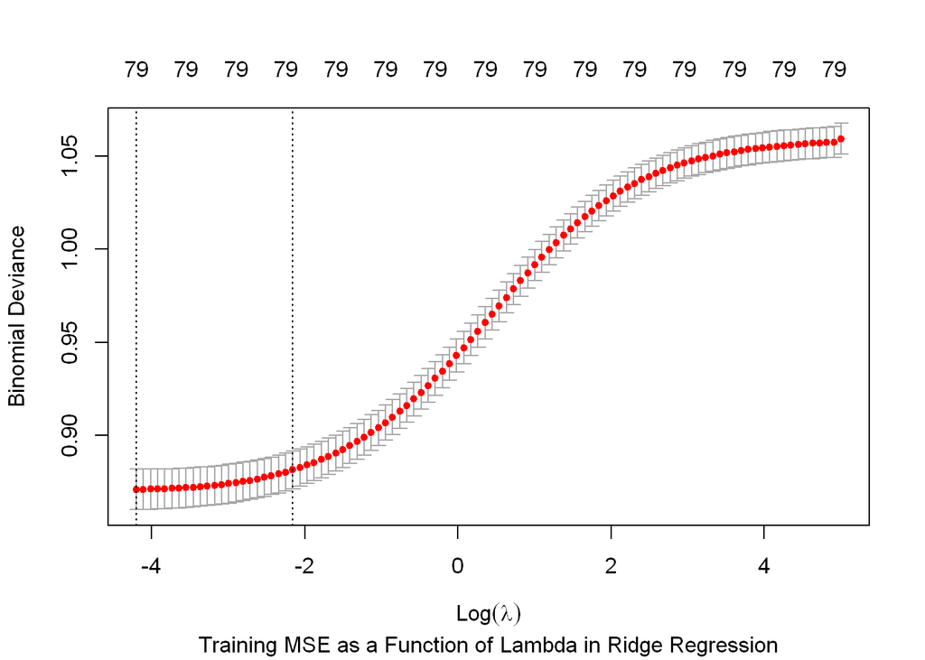

As lambda increases, deviance increases. This is related to the tradeoff between bias and deviance. As deviance increases, we have less bias.

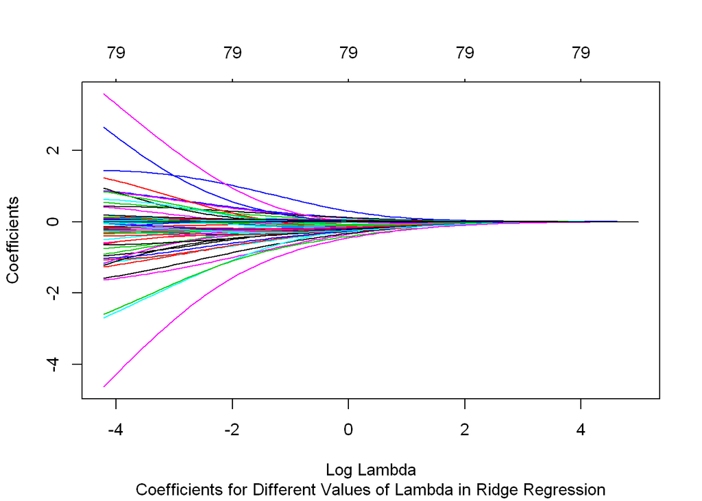

The ridge model does not have feature selection. Therefore, variables slowly converges to zero whereas the variables in lasso may sharlpy decrease to 0 as lambda increases. As penalty increases, more variables converge to zero.

```
##                     LIMIT_BAL                       SEXmale
##                  1.661062e-06                 -1.361582e-01
##          EDUCATIONhigh school               EDUCATIONothers
##                  1.756536e-03                  8.742573e-01
##           EDUCATIONuniversity              EDUCATIONunknown
##                 -4.037247e-02                  8.606922e-01
##                MARRIAGEothers                MARRIAGEsingle
##                  6.456639e-02                  1.286576e-01
##                           AGE             PAY_0paid in full
##                 -3.507986e-03                 -1.630770e-01
##  PAY_0payment delayed 1 month  PAY_0payment delayed 2 month
##                 -4.969004e-01                 -1.628793e+00
## PAY_0payment delayed 3 months PAY_0payment delayed 4 months
##                 -1.577554e+00                 -1.261570e+00
## PAY_0payment delayed 5 months PAY_0payment delayed 6 months
##                 -9.069509e-01                 -2.232731e-01
## PAY_0payment delayed 7 months PAY_0payment delayed 8 months
##                 -1.147306e+00                  1.055774e-01
##  PAY_0use of revolving credit             PAY_2paid in full
##                  4.274054e-01                  6.560073e-02
##  PAY_2payment delayed 1 month  PAY_2payment delayed 2 month
##                  5.365009e-01                 -2.116594e-01
## PAY_2payment delayed 3 months PAY_2payment delayed 4 months
##                 -2.624525e-01                  4.183582e-01
## PAY_2payment delayed 5 months PAY_2payment delayed 6 months
##                 -9.474963e-01                 -1.066636e+00
## PAY_2payment delayed 7 months PAY_2payment delayed 8 months
##                 -7.485074e-01                  1.431973e+00
##  PAY_2use of revolving credit             PAY_3paid in full
##                 -5.506756e-02                  6.232664e-02
##  PAY_3payment delayed 1 month  PAY_3payment delayed 2 month
##                  9.411059e-01                 -3.189696e-01
## PAY_3payment delayed 3 months PAY_3payment delayed 4 months
##                 -3.378665e-01                  1.185642e-01
## PAY_3payment delayed 5 months PAY_3payment delayed 6 months
##                  6.307373e-01                 -1.164618e+00
## PAY_3payment delayed 7 months PAY_3payment delayed 8 months
##                 -2.122372e-01                  1.226202e+00
##  PAY_3use of revolving credit             PAY_4paid in full
##                 -9.955529e-03                  7.372505e-02
```

[output cut: 25 more lines]

```
##                 -5.470686e-02                 -4.602558e+00
##  PAY_6use of revolving credit                     BILL_AMT1
##                  1.848355e-01                 -3.037793e-07
##                     BILL_AMT2                     BILL_AMT3
##                 -8.418378e-07                 -6.464863e-07
##                     BILL_AMT4                     BILL_AMT5
##                 -2.187557e-07                  1.389749e-08
##                     BILL_AMT6                      PAY_AMT1
##                  1.533201e-07                  8.129814e-06
##                      PAY_AMT2                      PAY_AMT3
##                  5.500552e-06                  2.300467e-06
##                      PAY_AMT4                      PAY_AMT5
##                  2.823587e-06                  3.132620e-06
##                      PAY_AMT6
##                  2.750934e-06
```

```
## [1] "Ridge regression accurately classified 81.6555555555556% of the data."
```

Although the ridge model coefficient estimates make sense, it still undeperformed when compared to the logit and probit models. The logistic and probit models both correctly classified ~82% of the data while the ridge model only correctly classified ~81.66%. However, the ridge model slightly outperforms the lasso model which correctly classified ~81.63% of the data. On the other hand, the KNN model still remains to have the highest error rate, only managing to correctly classify ~76.5% of the data.

### Lasso Regression

```
##
## Call:  cv.glmnet(x = cc_trn_x, y = cc_trn$default.payment.next.month,      alpha = 1, family = "binomial")
##
## Measure: Binomial Deviance
##
##       Lambda Measure       SE Nonzero
## min 0.001427  0.8693 0.010760      52
## 1se 0.010069  0.8796 0.009889      19
```

```
## [1] "The lambda within one standard error of the minimum lambda is 0.0014271864520944"
```

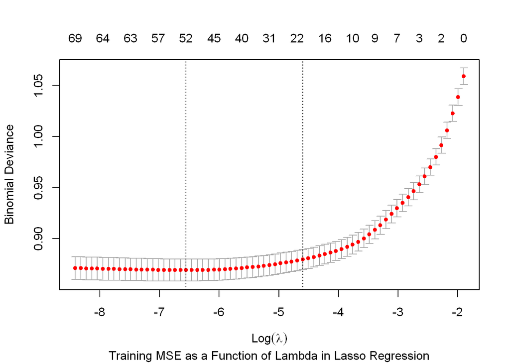

As the penalty increases, the deviance also increases. This is related to the tradeoff between bias and deviance. As deviance increases, we have less bias.

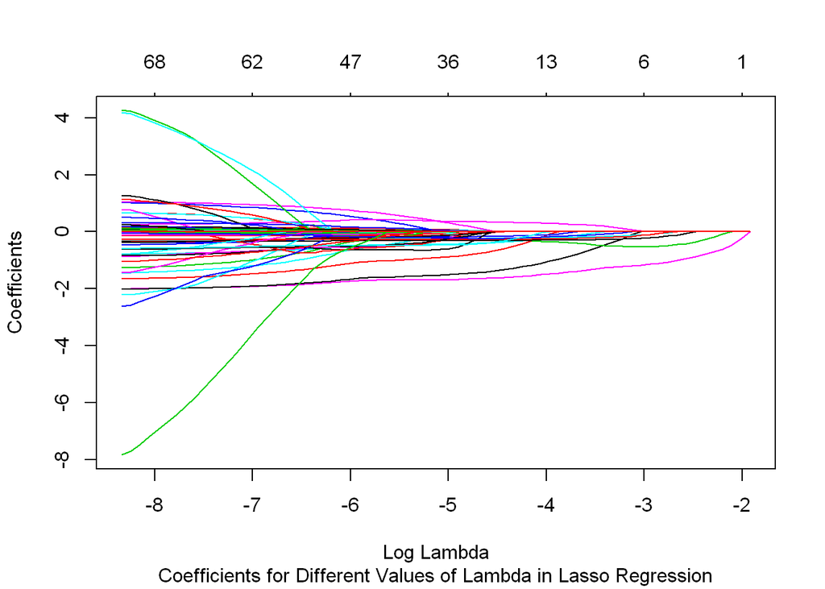

As stated previously, the lasso model has built in feature selecion.The lasso picks out non-important variables and set their coefficients to zero. This may cause sharp decreases to zero where as the variables in the ridge model slowly converges to zero. As the penalty increases, more non-important variables are selected.

```
## 80 x 1 sparse Matrix of class "dgCMatrix"
##                                           1
## (Intercept)                    1.282934e+00
## LIMIT_BAL                      1.833262e-06
## SEXmale                       -1.317952e-01
## EDUCATIONhigh school           .
## EDUCATIONothers                7.413715e-01
## EDUCATIONuniversity           -2.144408e-02
## EDUCATIONunknown               8.786389e-01
## MARRIAGEothers                 .
## MARRIAGEsingle                 1.287915e-01
## AGE                           -2.965077e-03
## PAY_0paid in full             -2.430045e-01
## PAY_0payment delayed 1 month  -6.328563e-01
## PAY_0payment delayed 2 month  -1.860616e+00
## PAY_0payment delayed 3 months -1.828286e+00
## PAY_0payment delayed 4 months -1.346042e+00
## PAY_0payment delayed 5 months -7.638013e-01
## PAY_0payment delayed 6 months -2.897274e-01
## PAY_0payment delayed 7 months -1.003132e+00
## PAY_0payment delayed 8 months  .
## PAY_0use of revolving credit   3.398330e-01
## PAY_2paid in full              9.599316e-02
## PAY_2payment delayed 1 month   2.962033e-01
## PAY_2payment delayed 2 month  -8.232628e-02
## PAY_2payment delayed 3 months -1.134548e-01
## PAY_2payment delayed 4 months  3.009446e-01
## PAY_2payment delayed 5 months -5.942216e-01
## PAY_2payment delayed 6 months -5.451947e-01
## PAY_2payment delayed 7 months -7.221375e-01
## PAY_2payment delayed 8 months  1.413121e-01
## PAY_2use of revolving credit   .
## PAY_3paid in full              5.198394e-02
## PAY_3payment delayed 1 month   .
## PAY_3payment delayed 2 month  -3.307121e-01
## PAY_3payment delayed 3 months -2.605054e-01
## PAY_3payment delayed 4 months  .
## PAY_3payment delayed 5 months  1.286879e-02
## PAY_3payment delayed 6 months -3.155071e-01
## PAY_3payment delayed 7 months -5.862294e-02
```

[output cut: 27 more lines]

```
## PAY_6payment delayed 7 months  .
## PAY_6payment delayed 8 months -1.914082e+00
## PAY_6use of revolving credit   2.357446e-01
## BILL_AMT1                      .
## BILL_AMT2                     -1.373813e-06
## BILL_AMT3                     -4.907284e-07
## BILL_AMT4                      .
## BILL_AMT5                      .
## BILL_AMT6                      .
## PAY_AMT1                       9.530053e-06
## PAY_AMT2                       5.986068e-06
## PAY_AMT3                       1.241629e-06
## PAY_AMT4                       1.772342e-06
## PAY_AMT5                       2.451019e-06
## PAY_AMT6                       1.890882e-06
```

```
## [1] "Lasso regression accurately classified 81.6333333333333% of the data."
```

The lasso model is slightly outperformed by the ridge model. The ridge model managed to correctly classified .03% more data than the lasso model. The lasso model also have a higher error rate than the logistic and probit models. On the other hand, the lasso model outperforms the KNN model due to the curse of high dimensionality.

### Classification Tree

```
##
## Classification tree:
## tree(formula = default.payment.next.month ~ ., data = cc_trn)
## Variables actually used in tree construction:
## [1] "PAY_0"    "PAY_2"    "PAY_AMT2"
## Number of terminal nodes:  4
## Residual mean deviance:  0.8862 = 18610 / 21000
## Misclassification error rate: 0.1792 = 3764 / 21000
```

The classification tree have 4 terminal nodes and 3 important variables. It considers the variables *PAY_0*, *PAY_2*, and *PAY_AMT2* important at classifying whether credit card payments will default or not. The classification tree managed to correctly classified 82.08% of the in the training dataset.

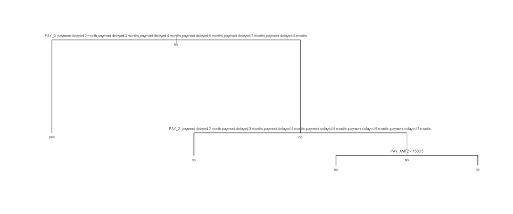

The most important indicator of whether credit card payments will default appears to be the repayment status in September, 2005. The first branch of the classification tree differentiates whether clients had no consumption, paid in full, used revolving credit, or delayed the payment for 1-8 months. The next most important indicator is the repayment status in August 2005. It also differentiates whether clients had no consumption, paid all their balance, used revolving credit, or delayed payment for 1-8 months. The third most important indicator is how much the client paid in the second month. It differentiates whether clients paid more than $1500.5. However, it appears that whether if the payment are above or below $1500.5, both groups are classified to not default on their credit card payments.

```
## [1] "Classification tree accurately classified 81.6888888888889% of the data."
```

The classification tree managed to accurately classified ~81.69% of the data. This is still not ideal in a business scenario. A model having an error rate of ~19% will cost significant losses for the credit card companies. Pruning the classification tree may improve the performance of the model.

```
## $size
## [1] 4 2 1
##
## $dev
## [1] 3767 3767 4666
##
## $k
## [1] -Inf    0  902
##
## $method
## [1] "misclass"
##
## attr(,"class")
## [1] "prune"         "tree.sequence"
```

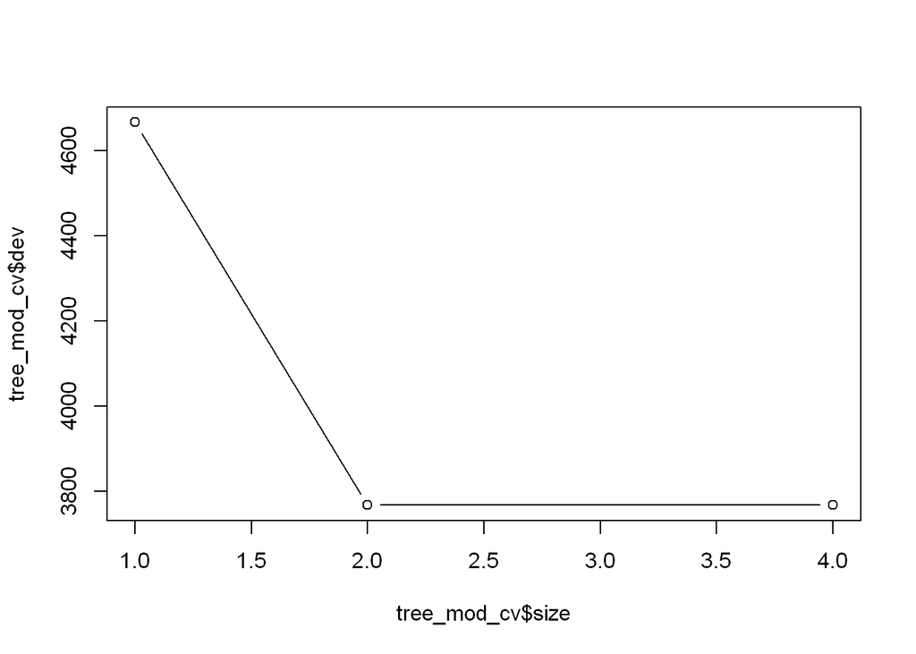

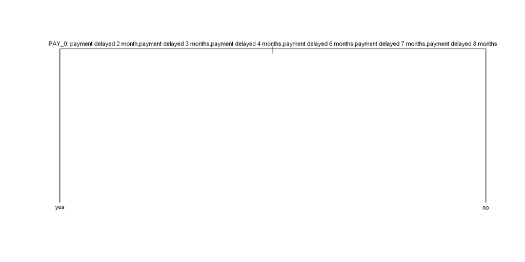

After pruning the classification tree, only one variable is left. The pruned classification tree model considers *PAY_0* to be the only feature needed to predict whether credit card payments will default. It differentiates whether clients had no consumption, paid in full, used revolving credits, or delayed the payment for 1-8 months.

```
## node), split, n, deviance, yval, (yprob)
##       * denotes terminal node
##
## 1) root 21000 22250 no ( 0.2222 0.7778 )
##   2) PAY_0: payment delayed 2 month,payment delayed 3 months,payment delayed 4 months,payment delayed 6 months,payment delayed 7 months,payment delayed 8 months 2206  2678 yes ( 0.7044 0.2956 ) *
##   3) PAY_0: no consummption,paid in full,payment delayed 1 month,payment delayed 5 months,use of revolving credit 18794 16870 no ( 0.1656 0.8344 ) *
```

The pruned classification tree only have one branch. If the clients had no consumption, paid all their balances, delayed their payments for 1 or 5 months, or used revolving credit in September 2005, then they are classified to not default on their credit card payments. On the other hand, if the clients had their payments delayed for 2,3,4,6,7, or 8 months, then the clients are classified to default on their card payments. This result does not really make sense in a business scenario. Clients that delayed their payments for 5 months are classified to not default on their payments while clients that delayed their payments for 2 months are. It would make more sense if clients that delayed their payments for 5 months are classified to default on their payments.

```
## [1] "Classification tree accurately classified 81.6888888888889% of the data."
```

### Bootstraping

```
##
## ORDINARY NONPARAMETRIC BOOTSTRAP
##
##
## Call:
## boot(data = cc_trn, statistic = boot_fn, R = 100, formula = default.payment.next.month ~
##     .)
##
##
## Bootstrap Statistics :
##      original        bias     std. error
## t1* 0.8168889 -7.777778e-06 0.0003810759
```

Decision trees are not very robust and suffer from having high variance. The prediction can change drastically with a small change in the sample. Therefore, bootstrapping should be used to to reduce the variance by averaging over multiple trees. The bootstrapped model accurately classified ~81.69% of the data with a std error of .00038 and a bias of -7.78 e^-06. The bootstrapped model have a less bias and variance. The bootstrapped model has an identical performance to the classification tree.

### Bagging

```
##
## Call:
##  randomForest(formula = default.payment.next.month ~ . - ID, data = cc_trn,      mtry = ncol(cc_trn) - 1, importance = TRUE)
##                Type of random forest: classification
##                      Number of trees: 500
## No. of variables tried at each split: 23
##
##         OOB estimate of  error rate: 18.33%
## Confusion matrix:
##      yes    no class.error
## yes 1784  2882  0.61765967
## no   968 15366  0.05926289
```

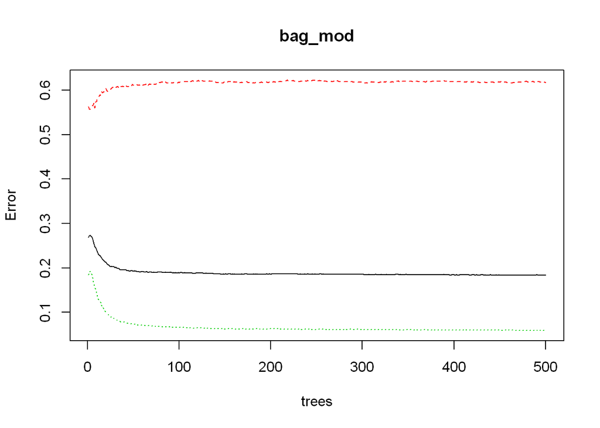

As the number of trees increase, the error rate starts to decrease and levels off. Variance decreases as we increase the number of trees.

```
## Confusion Matrix and Statistics
##
##           Reference
## Prediction  yes   no
##        yes  723  428
##        no  1247 6602
##
##                Accuracy : 0.8139
##                  95% CI : (0.8057, 0.8219)
##     No Information Rate : 0.7811
##     P-Value [Acc > NIR] : 1.001e-14
##
##                   Kappa : 0.36
##
##  Mcnemar's Test P-Value : < 2.2e-16
##
##             Sensitivity : 0.36701
##             Specificity : 0.93912
##          Pos Pred Value : 0.62815
##          Neg Pred Value : 0.84113
##              Prevalence : 0.21889
##          Detection Rate : 0.08033
##    Detection Prevalence : 0.12789
##       Balanced Accuracy : 0.65306
##
##        'Positive' Class : yes
##
```

```
## [1] "Bagging Classification tree accurately classified 81.3888888888889% of the data."
```

Bagging model accurately classified ~81.39% of the testing data. Out of 1970 clients that defaulted on their credit card payment, the bagging model only caught 723 cases. The bagging model has a false negative rate of ~63.3%. This is really high. Utilizing this model in real life would cause credit card companies to suffer a lot of losses as the model is bad at predicting positive cases. On the other hand, the model has a false positive rate of ~6.1%. The model performs decently at predicting negative cases. This means that the model will occassionally turn away good clients for credit card applications.

The bagging model have a higher error rate than the Lasso/Ridge model. The Ridge model misclassified 18.34% of the testing data while the Lasso model misclassified 18.36% of the testing data. The bagging model misclassified 18.61% of the data, slightly higher than the error rate of the Lasso and Ridge models. The bagging model also have a higher error rate than the logistic model, the probit model, the classification tree model, and the boostrap tree model. However, it did manage to perform better than the KNN model which had an error rate of 23.5%.

```
##                  yes         no MeanDecreaseAccuracy MeanDecreaseGini
## LIMIT_BAL  19.182476  21.769037            28.891229        450.64390
## SEX        -1.924070   5.047149             3.407947         59.22184
## EDUCATION  -2.097800   7.978057             5.730147        140.95399
## MARRIAGE   -5.607034  18.567454            14.650514         76.74884
## AGE         2.049547  29.033931            27.742907        566.06804
## PAY_0     122.649122 107.575994           177.452561       1210.79138
## PAY_2      10.393669  52.093478            63.562702        264.66679
## PAY_3      11.914752  31.755646            38.836298         86.64990
## PAY_4       5.611669  32.139219            37.862323         70.66421
## PAY_5       5.933912  30.614477            37.092647         72.63727
## PAY_6      23.664795  32.777273            48.764134         92.60930
## BILL_AMT1  22.324313  19.110551            29.591640        460.98722
## BILL_AMT2 -14.815029  45.457815            48.229967        327.06956
## BILL_AMT3 -14.115849  45.819416            48.287510        314.37423
## BILL_AMT4 -18.045527  50.522630            53.044367        304.95185
## BILL_AMT5  -5.916044  41.264169            46.513121        299.52241
## BILL_AMT6   8.218083  30.039235            39.090316        326.92237
## PAY_AMT1   -7.561595  38.189996            40.256303        341.45676
## PAY_AMT2    2.565895  30.990050            35.132920        385.78308
## PAY_AMT3   10.279756  30.654742            39.223096        369.05215
## PAY_AMT4    9.426616  29.278779            36.016264        316.62259
## PAY_AMT5    3.076627  32.911603            38.254631        327.03450
## PAY_AMT6   14.792542  31.013857            40.094221        375.98113
```

The variable *Pay_0* have the largest magnitude value by far. This indicates that the most recent payment amount made by the client is the most important variable at determining whether the payment will default or not. This makes sense. If a client doesn’t pay or pays a small fraction of the amount owed, it is very likely that the client is unable to pay back what they owed. This makes the client highly at risk for defaulting. All of the other variables also have some form of effect on whether payments will default as their importantce matrix coefficients are not 0. Some examples of other notable predictors are the most recent bill amount, the balance limit on the account, and the first payment amount. These variables have a magnitude in the 20s, The balance limit, payment amount, and bill amount are all reasonable predictors for predicting whether payments will default. Higher bill amounts are harder to pay off, a low balance limit indicates lower income or credit score, and a low payment amount may indicate finacial inability to pay back what was owed.